# savingSessions: tweet analysis

Author

Ben Anderson (@dataknut)

Published

December 7, 2022

# 1 Background

UK demand response experiments by NG-ESO and retailers such as [@OctopusEnergy](https://twitter.com/SavingSessions)

Attempt to do some analysis of #savingSession(s) tweets.

# 2 Code setup

Part of https://github.com/dataknut/savingSessions

Makes use of https://github.com/dataknut/hashTagR, a DIY wrapper for the rtweet rstats package.

# 3 Getting data

Grab the most recent set of tweets that mention #savingSession OR #savingSessions OR #savingsession using the [rtweet::search_tweet()](https://docs.ropensci.org/rtweet/reference/search_tweets.html) function and merge with any we may already have downloaded.

Note that tweets do not seem to be available after ~ 14 days via the API used by rtweet. Best to keep refreshing the data every week…

```
[1] "Found 45 files matching *.csv in ~/Dropbox/data/twitter/savingSessions/"
```

That produced a data file of 2793 tweets.

We do NOT store the tweets in the repo for both [ethical](https://blogs.lse.ac.uk/impactofsocialsciences/2015/09/28/challenges-of-using-twitter-as-a-data-source-resources/) and practical reasons…

Note also that we may not be collecting the complete dataset of hashtagged tweets due to the [intricacies of the twitter API](https://www.demos.co.uk/files/Road_to_representivity_final.pdf?1441811336).

# 4 Analysis

## 4.1 Tweet time line

Figure 1 shows the timing of tweets by hour.

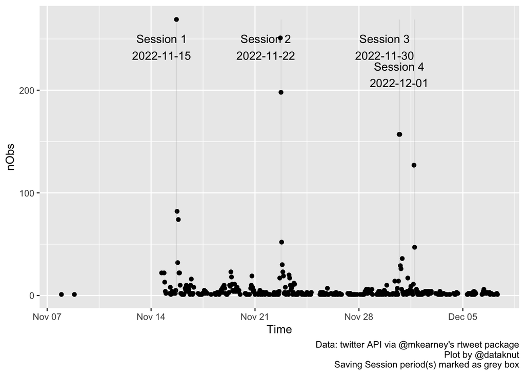

Figure 1: Tweets over time

Figure 2 shows cumulative tweets by hour.

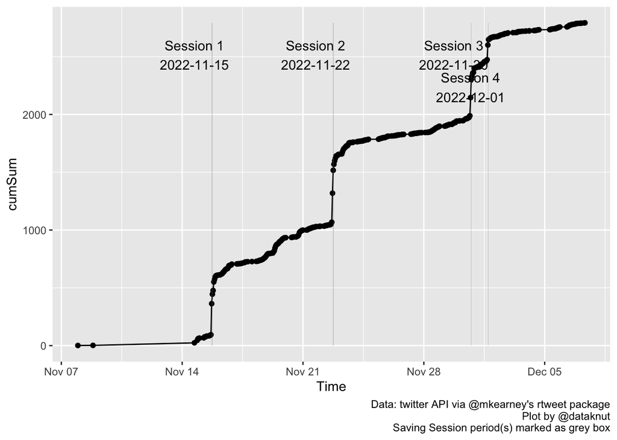

Figure 2: Cumulative number of tweets over time

We see roughly the kind of uptick in tweets for Session 2 that we saw for Session 1…

## 4.2 Sentiment analysis

Yeah…

## 4.3 Content analysis

Yeah…

# 5 The end